# Guided Practice

Soumya Mukherjee

```r
# clean up R environment
rm(list = ls())

# libraries
library(tidyverse)
#devtools::install_github("cran/mdsr")
library(mdsr)
library(mosaic)
# data intake
data("SAT_2010", package = "mdsr")
```

## Guided Example: SAT Data exploration

**Statement of Research Question**

Are higher teacher salaries associated with better state-wide SAT scores?

## Examine the data source

for example:

- review data intake
- variable types,
- coding,
- missingness,
- who/what/when/where/why/how data were collected
- basic summary statistics and plots to learn about variables

```r
#examine the data source

# review data intake & variable coding
help(SAT_2010)
glimpse(SAT_2010)
```

```
Rows: 50
Columns: 9
$ state               <fct> Alabama, Alaska, Arizona,…
$ expenditure         <int> 10, 17, 9, 10, 10, 10, 16…
$ pupil_teacher_ratio <dbl> 15.3, 16.2, 21.4, 14.1, 2…
$ salary              <int> 49948, 62654, 49298, 4903…
$ read                <int> 556, 518, 519, 566, 501, …
$ math                <int> 550, 515, 525, 566, 516, …
$ write               <int> 544, 491, 500, 552, 500, …
$ total               <int> 1650, 1524, 1544, 1684, 1…
$ sat_pct             <int> 8, 52, 28, 5, 53, 19, 87,…
```

```r
head(SAT_2010)
```

|  | state | expenditure | pupil_teacher_ratio | salary | read | math | write | total | sat_pct |
| --- | --- | --- | --- | --- | --- | --- | --- | --- | --- |
| 1 | Alabama | 10 | 15.3 | 49948 | 556 | 550 | 544 | 1650 | 8 |
| 2 | Alaska | 17 | 16.2 | 62654 | 518 | 515 | 491 | 1524 | 52 |
| 3 | Arizona | 9 | 21.4 | 49298 | 519 | 525 | 500 | 1544 | 28 |
| 4 | Arkansas | 10 | 14.1 | 49033 | 566 | 566 | 552 | 1684 | 5 |
| 5 | California | 10 | 24.1 | 71611 | 501 | 516 | 500 | 1517 | 53 |
| 6 | Colorado | 10 | 17.4 | 51660 | 568 | 572 | 555 | 1695 | 19 |

```r
tail(SAT_2010)
```

|  | state | expenditure | pupil_teacher_ratio | salary | read | math | write | total | sat_pct |
| --- | --- | --- | --- | --- | --- | --- | --- | --- | --- |
| 45 | Vermont | 17 | 11.6 | 51537 | 519 | 521 | 506 | 1546 | 67 |
| 46 | Virginia | 11 | 17.6 | 52514 | 512 | 512 | 497 | 1521 | 71 |
| 47 | Washington | 10 | 19.4 | 55651 | 524 | 532 | 508 | 1564 | 57 |
| 48 | West Virginia | 12 | 13.9 | 48255 | 515 | 507 | 500 | 1522 | 17 |
| 49 | Wisconsin | 12 | 15.1 | 53826 | 595 | 604 | 579 | 1778 | 5 |
| 50 | Wyoming | 17 | 12.5 | 58652 | 570 | 567 | 546 | 1683 | 5 |

```r
# missingness & summary statistics (using favstats function from mosaic package)
favstats( ~ salary, data = SAT_2010)
```

|  | min | Q1 | median | Q3 | max | mean | sd | n | missing |
| --- | --- | --- | --- | --- | --- | --- | --- | --- | --- |
|  | 40778 | 48999.25 | 52062.5 | 58728.5 | 75212 | 54721.28 | 7755.489 | 50 | 0 |

```r
favstats( ~ total, data = SAT_2010)
```

|  | min | Q1 | median | Q3 | max | mean | sd | n | missing |
| --- | --- | --- | --- | --- | --- | --- | --- | --- | --- |
|  | 1389 | 1489.25 | 1559 | 1692.25 | 1798 | 1596.46 | 116.7002 | 50 | 0 |

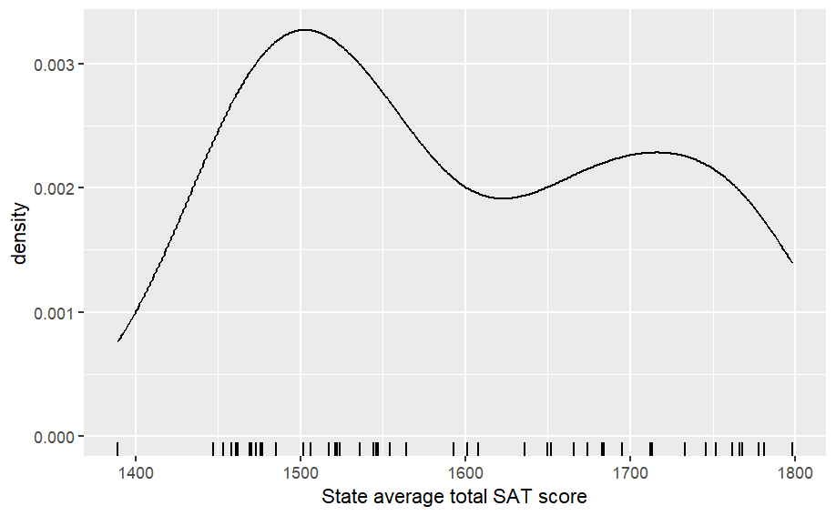

```r
SAT_2010 %>%
    ggplot(aes(x = salary)) +
    geom_density() +
    geom_rug() +
    xlab("State average teacher salary (US dollars)")

SAT_2010 %>%
    ggplot(aes(x = total)) +
    geom_density() +
    geom_rug() +
    xlab("State average total SAT score")
```

[output not shown]

#### who/what/when/where/why/how data were collected?

- average teacher salaries (in 2010) & average SAT scores for each of the 50 states
- https://mdsr-book.github.io/mdsr2e/ch-foundations.html
- there’s isn’t much additional detail in the MDSR book about the origins of the data, so we might want to contact authors of “Modern Data Science with R” book to learn more about the data collection process

## Discover features in the data that may impact modeling decisions

Some of this is based on scrutiny of the data collection practices (and study design), but much of it can be substantiated in EDA

- functionally dichotomous variables–e.g., survey asks people to rate job approval of a contraversial president on scale of 1-7 yet most people choose either 1 or 7 and the options in between are rarely used
- highly correlated predictor variables (i.e., strong relationships)
- hierarchy or nesting–e.g., data from students within classrooms within schools (within states…)
- repeated observations of the same “case”–e.g., medical study follows up with the same group of patients every 6 months
- investigate potential outliers

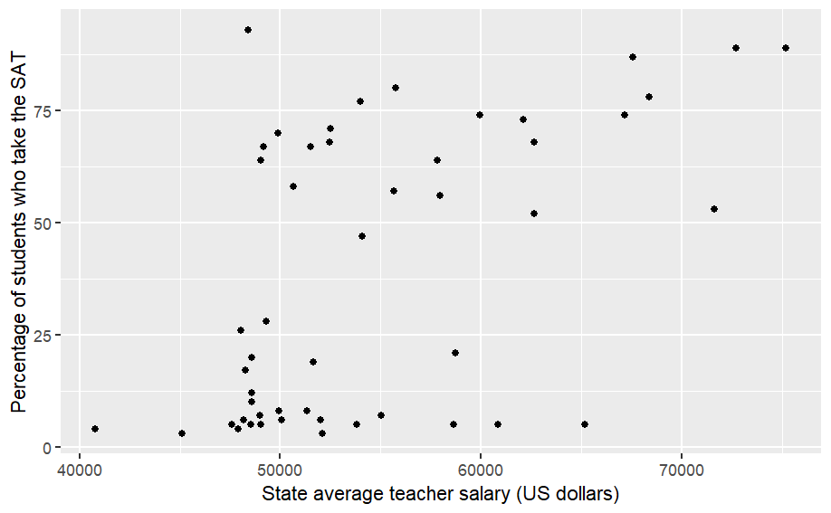

```r
SAT_2010 %>%
    ggplot(aes(x = salary, y = sat_pct)) +
    geom_point() +
    # geom_smooth() +     # if linear is reasonable, consider method = "lm"
    xlab("State average teacher salary (US dollars)") +
    ylab("Percentage of students who take the SAT")
```

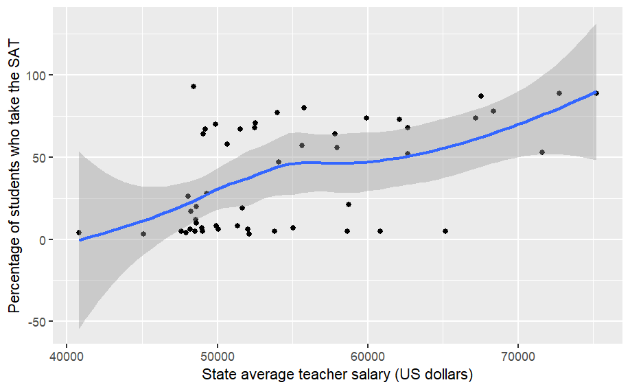

```r
SAT_2010 %>%
    ggplot(aes(x = salary, y = sat_pct)) +
    geom_point() +
    geom_smooth() +
    xlab("State average teacher salary (US dollars)") +
    ylab("Percentage of students who take the SAT")
```

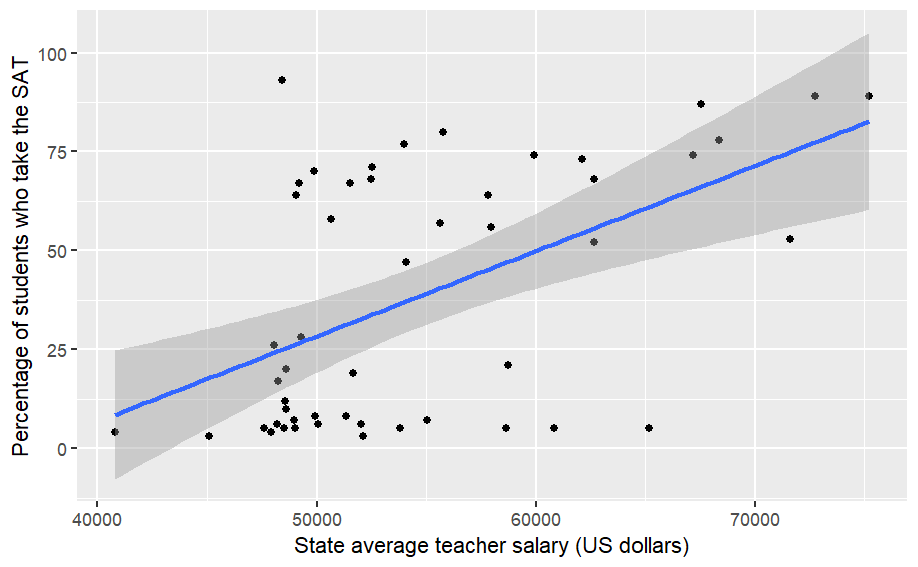

```r
SAT_2010 %>%
    ggplot(aes(x = salary, y = sat_pct)) +
    geom_point() +
    geom_smooth(method = "lm") +
    xlab("State average teacher salary (US dollars)") +
    ylab("Percentage of students who take the SAT")
```

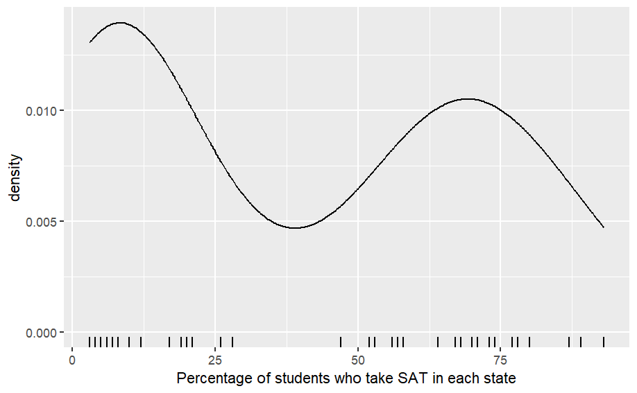

```r
# density of sat_rate... apparent gap (why??)
SAT_2010 %>%
    ggplot(aes(x = sat_pct)) +
    geom_density() +
    geom_rug() +
    xlab("Percentage of students who take SAT in each state")
```

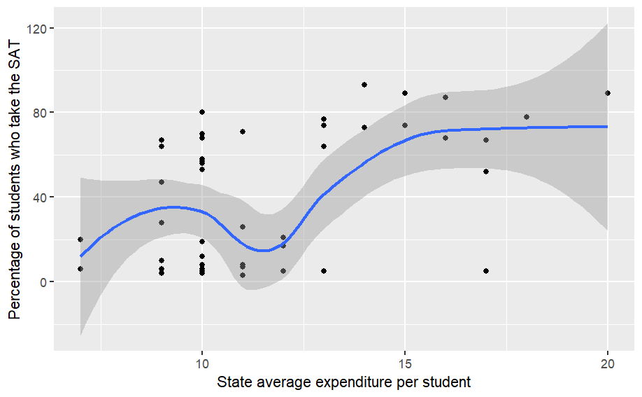

```r
SAT_2010 <-
    SAT_2010 %>%
    mutate(sat_rate = cut(sat_pct, breaks = c(0, 30, 70, 100),
                          labels = c("low", "med", "high")))
    # mutate(sat_rate = cut(sat_pct, breaks = c(0, 40, 100),
    #                       labels = c("lower", "higher")))

SAT_2010 %>%
    ggplot(aes(x = expenditure, y = sat_pct)) +
    geom_point() +
    geom_smooth() +
    xlab("State average expenditure per student") +
    ylab("Percentage of students who take the SAT")
```

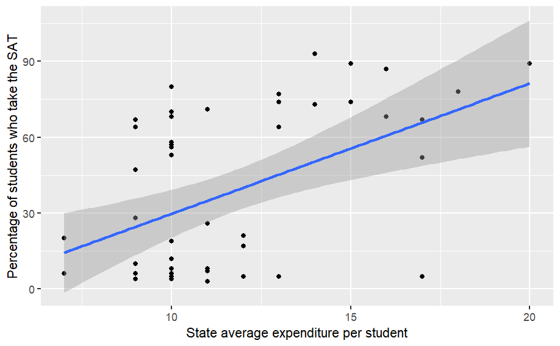

```r
SAT_2010 %>%
    ggplot(aes(x = expenditure, y = sat_pct)) +
    geom_point() +
    geom_smooth(method = "lm") +
    xlab("State average expenditure per student") +
    ylab("Percentage of students who take the SAT")
```

```r
SAT_2010 %>%
    filter(sat_pct < 25, expenditure > 15)
```

| state | expenditure | pupil_teacher_ratio | salary | read | math | write | total | sat_pct | sat_rate |
| --- | --- | --- | --- | --- | --- | --- | --- | --- | --- |
| Wyoming | 17 | 12.5 | 58652 | 570 | 567 | 546 | 1683 | 5 | low |

## Address research question

- one or a few key data visualizations that are most informative to a reader/observer
- must include data visualization (but not exclusively)
- often requires exploring many data visualizations to find the one or few that most effectively communicate intuition for your research question
- we may even do some exploratory modeling here

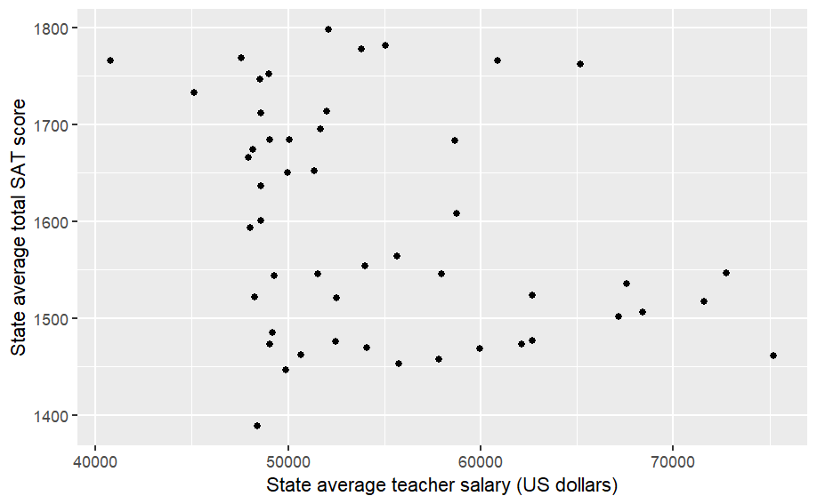

```r
## Relationship b/w salary and Average total SAT scores

SAT_2010 %>%
    ggplot(aes(x = salary, y = total)) +
    geom_point() +
    # geom_smooth() +
    # geom_smooth(method = "lm") +
    xlab("State average teacher salary (US dollars)") +
    ylab("State average total SAT score")
```

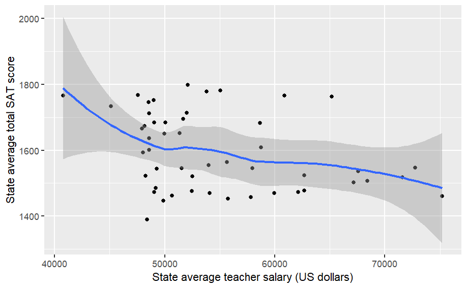

```r
SAT_2010 %>%
    ggplot(aes(x = salary, y = total)) +
    geom_point() +
    geom_smooth() +
    # geom_smooth(method = "lm") +
    xlab("State average teacher salary (US dollars)") +
    ylab("State average total SAT score")
```

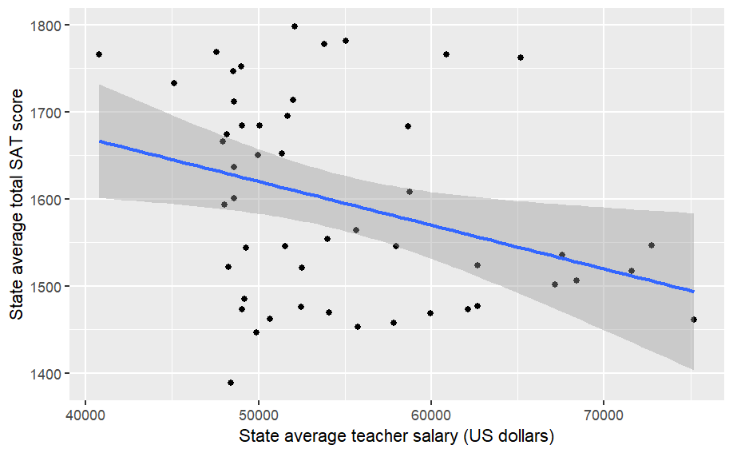

```r
SAT_2010 %>%
    ggplot(aes(x = salary, y = total)) +
    geom_point() +
    geom_smooth(method = "lm") +
    xlab("State average teacher salary (US dollars)") +
    ylab("State average total SAT score")
```

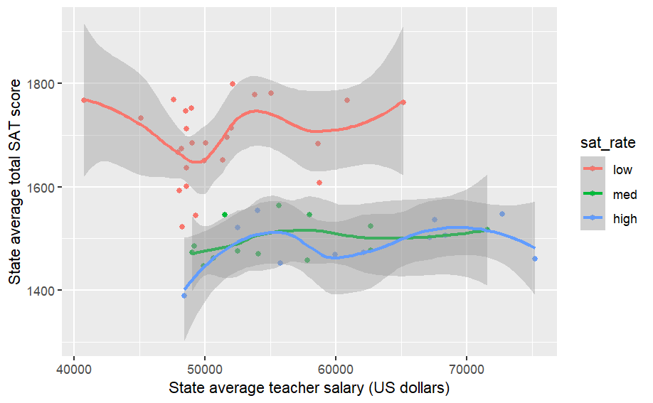

```r
SAT_2010 %>%
    ggplot(aes(x = salary, y = total, color = sat_rate)) +
    geom_point() +
    geom_smooth() +
    # geom_smooth(method = "lm") +
    xlab("State average teacher salary (US dollars)") +
    ylab("State average total SAT score")
```

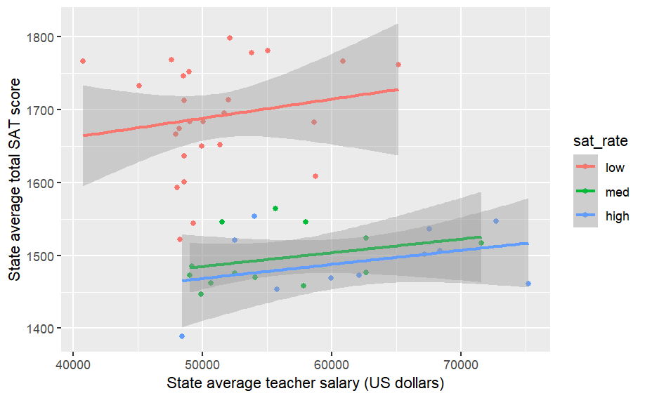

```r
SAT_2010 %>%
    ggplot(aes(x = salary, y = total, color = sat_rate)) +
    geom_point() +
    geom_smooth(method = "lm") +
    xlab("State average teacher salary (US dollars)") +
    ylab("State average total SAT score")
```

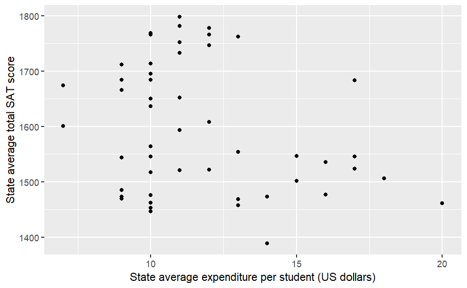

```r
SAT_2010 %>%
    ggplot(aes(x = expenditure, y = total)) +
    geom_point() +
    # geom_smooth() +
    # geom_smooth(method = "lm") +
    xlab("State average expenditure per student (US dollars)") +
    ylab("State average total SAT score")
```

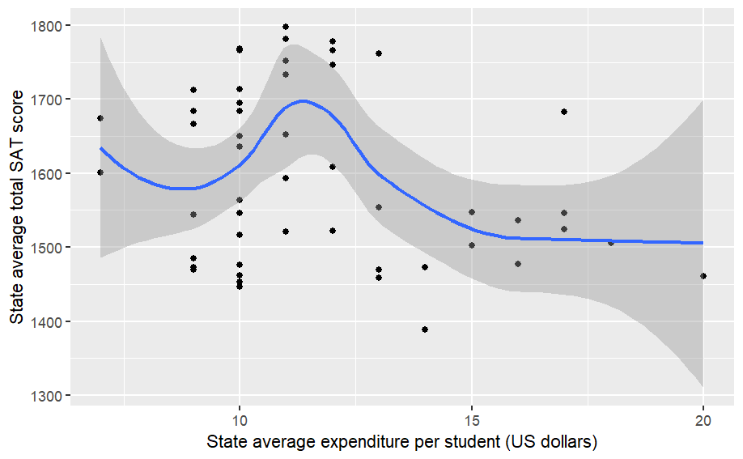

```r
SAT_2010 %>%
    ggplot(aes(x = expenditure, y = total)) +
    geom_point() +
    geom_smooth() +
    xlab("State average expenditure per student (US dollars)") +
    ylab("State average total SAT score")
```

```
Mapping API still under development and may change in future releases.
```

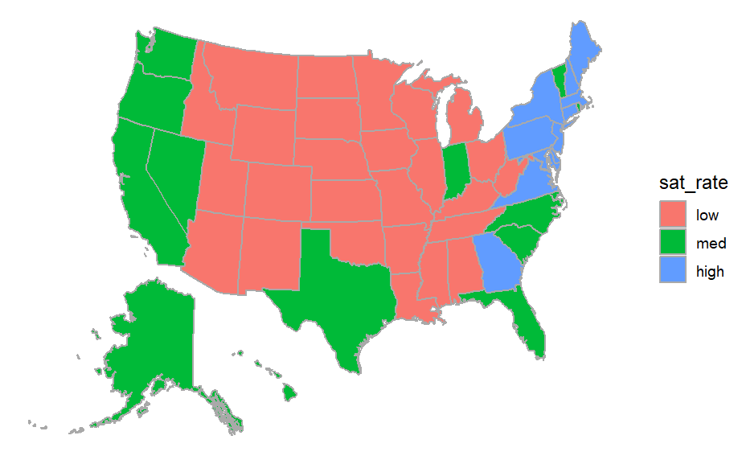

```r
# since we have state data, maybe we should map it!
library(mosaic)
mUSMap(SAT_2010, key = "state", "fill" = "sat_rate")
```

```
Mapping API still under development and may change in future releases.
```

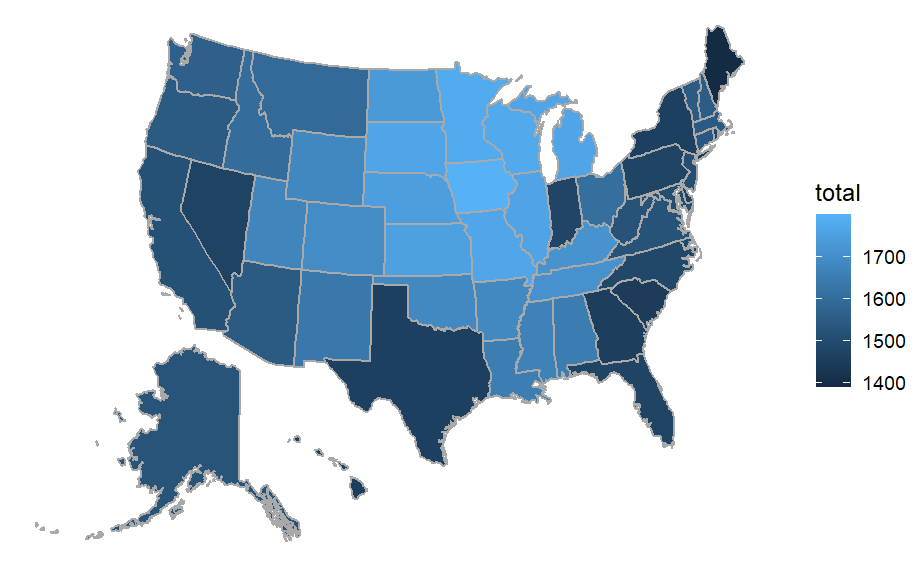

```r
mUSMap(SAT_2010, key = "state", "fill" = "total")
```

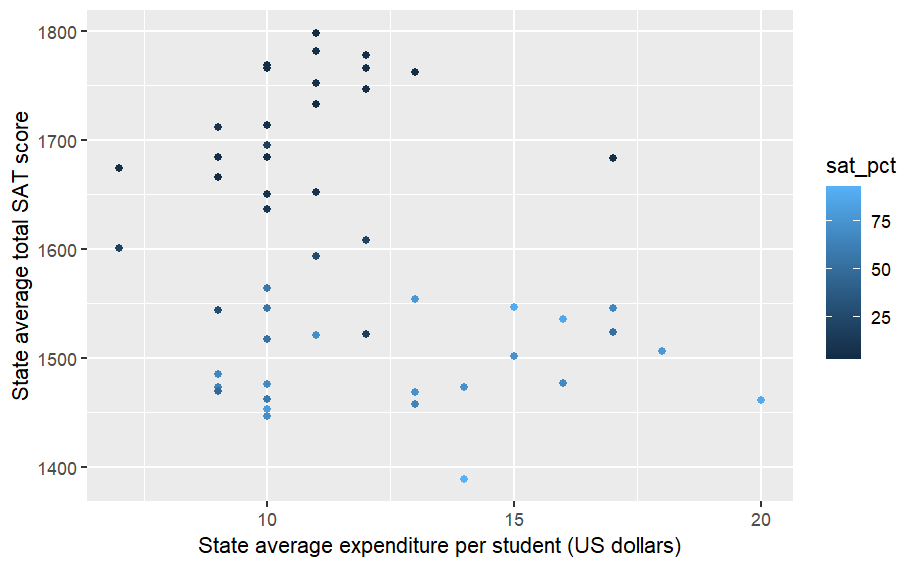

```r
## relationship between expenditure and salary
SAT_2010 %>%
    ggplot(aes(x = expenditure, y = total, color = sat_pct)) +
    geom_point() +
    # geom_smooth() +
    # geom_smooth(method = "lm") +
    xlab("State average expenditure per student (US dollars)") +
    ylab("State average total SAT score")
```

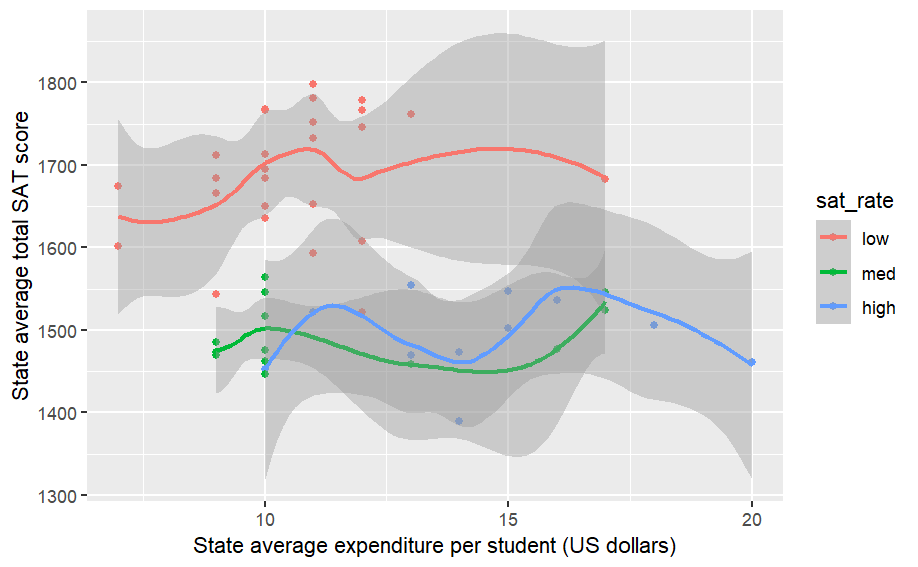

```r
SAT_2010 %>%
    ggplot(aes(x = expenditure, y = total, color = sat_rate)) +
    geom_point() +
    geom_smooth() +
    xlab("State average expenditure per student (US dollars)") +
    ylab("State average total SAT score")
```

## Statistical modeling

After we have completed a thorough EDA, we are ready for inferential or predictive modeling. Although we might discover new questions and come back for **more** EDA! It’s a process.

Even fancy statistical models can certainly be used for exploratory and descriptive purposes during EDA (e.g., we fit smoothers & regression lines above), but they do impose a kind of structure on the data that influences (biases) our expectations.

It’s good advice to learn as much as you can can while imposing as little additional structure as possible, and then gradually adding more structure to progressively refine our understanding.

Ideally, we want to let the data speak for itself, and then use appropriate analytical results like models to simply refine interpretations/predictions and more precisely quantify the uncertainty of our conclusions.